```python
import pandas as pd
```

# Task1.1 Read the dataset

```python
df = pd.read_excel("TWTR.xlsx")
```

# Task1.1 Display First 100 Rows

```python
df.head(100)
```

|  | Date | Open | High | Low | Close | Adj Close | Volume |
| --- | --- | --- | --- | --- | --- | --- | --- |
| 0 | 2018-01-01 | 45.099998 | 50.090000 | 44.000000 | 44.900002 | 44.900002 | 117701670.0 |
| 1 | 2018-01-02 | 45.930000 | 46.939999 | 40.685001 | 41.650002 | 41.650002 | 27925307.0 |
| 2 | 2018-01-03 | 40.500000 | 43.000000 | 39.400002 | 42.900002 | 42.900002 | 16113941.0 |
| 3 | 2018-01-04 | 43.660000 | 43.779999 | 41.830002 | 41.900002 | 41.900002 | 6316755.0 |
| 4 | 2018-01-05 | 41.029999 | 42.869999 | 40.759998 | 42.599998 | 42.599998 | 8688325.0 |
| ... | ... | ... | ... | ... | ... | ... | ... |
| 95 | 2018-04-06 | 45.090000 | 46.400002 | 43.310001 | 46.320000 | 46.320000 | 15507597.0 |
| 96 | 2018-04-07 | 46.650002 | 47.340000 | 45.700001 | 47.299999 | 47.299999 | 9610491.0 |
| 97 | 2018-04-08 | 47.549999 | 47.750000 | 46.430000 | 46.669998 | 46.669998 | 5794497.0 |
| 98 | 2018-04-09 | 46.709999 | 47.590000 | 46.180000 | 46.980000 | 46.980000 | 6916147.0 |
| 99 | 2018-04-10 | 47.400002 | 47.439999 | 45.509998 | 45.730000 | 45.730000 | 7911260.0 |

100 rows × 7 columns

# Task1.2 Column Insights

```python
print("Shape of Dataset:",df.shape)
```

```
Shape of Dataset: (2264, 7)
```

```python
df.info()
```

```
<class 'pandas.core.frame.DataFrame'>
RangeIndex: 2264 entries, 0 to 2263
Data columns (total 7 columns):
 #   Column     Non-Null Count  Dtype
---  ------     --------------  -----
 0   Date       2264 non-null   datetime64[ns]
 1   Open       2259 non-null   float64
 2   High       2259 non-null   float64
 3   Low        2259 non-null   float64
 4   Close      2259 non-null   float64
 5   Adj Close  2259 non-null   float64
 6   Volume     2259 non-null   float64
dtypes: datetime64[ns](1), float64(6)
memory usage: 123.9 KB
```

```python
df.columns
```

```
Index(['Date', 'Open', 'High', 'Low', 'Close', 'Adj Close', 'Volume'], dtype='object')
```

# Task1.3 Null Values

```python
df.isnull().sum()
```

```
Date         0
Open         5
High         5
Low          5
Close        5
Adj Close    5
Volume       5
dtype: int64
```

# Task1.3 Remove the null values

```python
df = df.dropna()
```

```python
df.isnull().sum()
```

```
Date         0
Open         0
High         0
Low          0
Close        0
Adj Close    0
Volume       0
dtype: int64
```

## Handling missing values

The dataset contained 5 missing values in each numerical column. Since these missing values represented only a very small fraction of the dataset, the rows containing missing values were removed using the 'dropna()' function. This ensured a clean dataset for further statistical analysis and visualization.

```python
print("New Shape:",df.shape)
```

```
New Shape: (2259, 7)
```

# Task1.4 Statistical Description

```python
df.describe()
```

|  | Date | Open | High | Low | Close | Adj Close | Volume |
| --- | --- | --- | --- | --- | --- | --- | --- |
| count | 2259 | 2259.000000 | 2259.000000 | 2259.000000 | 2259.000000 | 2259.000000 | 2.259000e+03 |
| mean | 2021-02-03 00:00:00 | 36.020286 | 36.699881 | 35.339465 | 36.003625 | 36.003625 | 2.175186e+07 |
| min | 2018-01-01 00:00:00 | 13.950000 | 14.220000 | 13.725000 | 14.010000 | 14.010000 | 0.000000e+00 |
| 25% | 2019-07-19 12:00:00 | 25.550000 | 26.215001 | 24.912501 | 25.410000 | 25.410000 | 1.233530e+07 |
| 50% | 2021-02-03 00:00:00 | 35.419998 | 36.099998 | 34.820000 | 35.490002 | 35.490002 | 1.691305e+07 |
| 75% | 2022-08-21 12:00:00 | 44.205000 | 45.015000 | 43.327501 | 44.135000 | 44.135000 | 2.428082e+07 |
| max | 2024-03-08 00:00:00 | 78.360001 | 80.750000 | 76.050003 | 77.629997 | 77.629997 | 2.692131e+08 |
| std | NaN | 14.118463 | 14.372057 | 13.828724 | 14.089989 | 14.089989 | 1.909988e+07 |

## Statistical Insights

- The dataset contains 2,259 observations after removing missing values.
- The average opening price is approximately 36.02 USD.
- The average closing price is approximately 36.00 USD.
- The stock reached a maximum closing price of about 77.63 USD.
- The minimum closing price observed was around 14.01 USD.
- The standard deviation of the closing price is about 14.09, indicating moderate price volatility.
- Trading volume ranges from 0 to approximately 269 mn shares, showing significant variation in trading activity.

# Task1.5 Missing Values

```python
df.describe(include='all')
```

|  | Date | Open | High | Low | Close | Adj Close | Volume |
| --- | --- | --- | --- | --- | --- | --- | --- |
| count | 2259 | 2259.000000 | 2259.000000 | 2259.000000 | 2259.000000 | 2259.000000 | 2.259000e+03 |
| mean | 2021-02-03 00:00:00 | 36.020286 | 36.699881 | 35.339465 | 36.003625 | 36.003625 | 2.175186e+07 |
| min | 2018-01-01 00:00:00 | 13.950000 | 14.220000 | 13.725000 | 14.010000 | 14.010000 | 0.000000e+00 |
| 25% | 2019-07-19 12:00:00 | 25.550000 | 26.215001 | 24.912501 | 25.410000 | 25.410000 | 1.233530e+07 |
| 50% | 2021-02-03 00:00:00 | 35.419998 | 36.099998 | 34.820000 | 35.490002 | 35.490002 | 1.691305e+07 |
| 75% | 2022-08-21 12:00:00 | 44.205000 | 45.015000 | 43.327501 | 44.135000 | 44.135000 | 2.428082e+07 |
| max | 2024-03-08 00:00:00 | 78.360001 | 80.750000 | 76.050003 | 77.629997 | 77.629997 | 2.692131e+08 |
| std | NaN | 14.118463 | 14.372057 | 13.828724 | 14.089989 | 14.089989 | 1.909988e+07 |

# Task2.1 T-Test

```python
from scipy.stats import ttest_ind
t_stat, p_value = ttest_ind(df['High'],df['Low'])
print("T-Statistic:",t_stat)
print("P-Value:",p_value)
if p_value<0.5:
    print("Reject the Null Hypothesis")
    print("There is a statistically significant difference between High and Low prices.")
else:
    print("Fail to reject the null hypothesis")
    print("There is no statistically significant difference.")
```

```
T-Statistic: 3.2419259809614287
P-Value: 0.0011958722702637662
Reject the Null Hypothesis
There is a statistically significant difference between High and Low prices.
```

# Task2.2 Chi-Square Test

```python
from scipy.stats import chi2_contingency
df['High_Category']=(df['High']>
                     df['High'].median()).astype(int)
df['Close_category']=(df['Close']>
                      df['Close'].median()).astype(int)
contingency_table=pd.crosstab(df['High_Category'],df['Close_category'])
chi2,p,dof,expected = chi2_contingency(contingency_table)
print("Chi-Square Statistics:",chi2)
print("P-Value:",p)
if p<0.05:
    print("Reject the null hypothesis")
    print("High Price and Close Price are dependent.")
else:
    print("Fail to reject the null hypothesis")
    print("High Price and Close Price are independent.")
```

```
Chi-Square Statistics: 2144.4891323453985
P-Value: 0.0
Reject the null hypothesis
High Price and Close Price are dependent.
```

## Interpretation

The Chi-Square test was performed to examine whether High prices and Closing prices are associated. Since the p-value is less than 0.05, the null hypothesis is rejected. This indicates a statistically significant relationship between the High price and the Closing price. Therefore, changes in the High price are strongly associated with changes in the Closing price.

# Task3.1 Stock Prices Over The Years

```python
import matplotlib.pyplot as plt
```

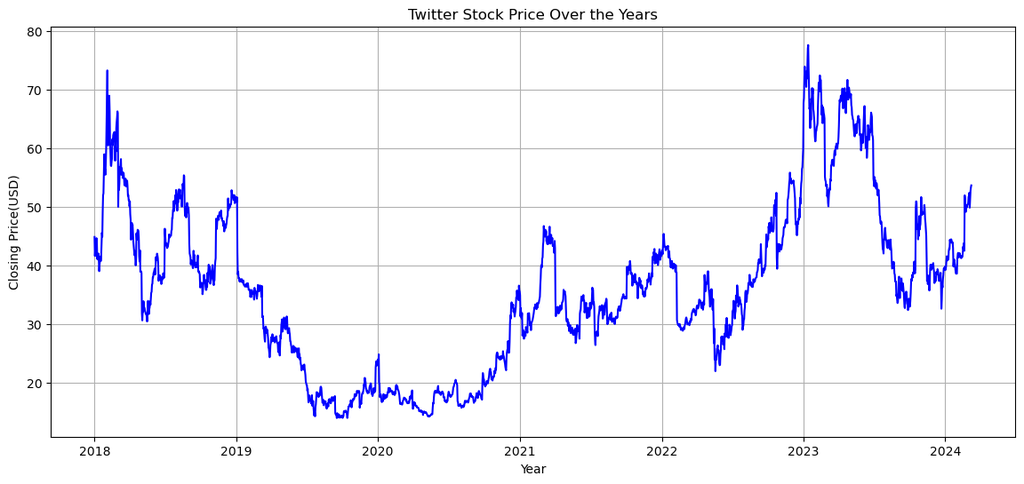

```python
plt.figure(figsize=(14,6))
plt.plot(df['Date'],df['Close'],color='blue')
plt.title("Twitter Stock Price Over the Years")
plt.xlabel("Year")
plt.ylabel("Closing Price(USD)")
plt.grid(True)
plt.show()
```

## Conclusion

The line chart shows that Twitter's stock price fluctuated considerably between 2018 and 2024. There were periods of growth followed by declines, indicating market volatility. Overall, the stock experienced several significant price movements driven by market conditions and company-specific events.

# Task3.2 Compare Close Price vs Date

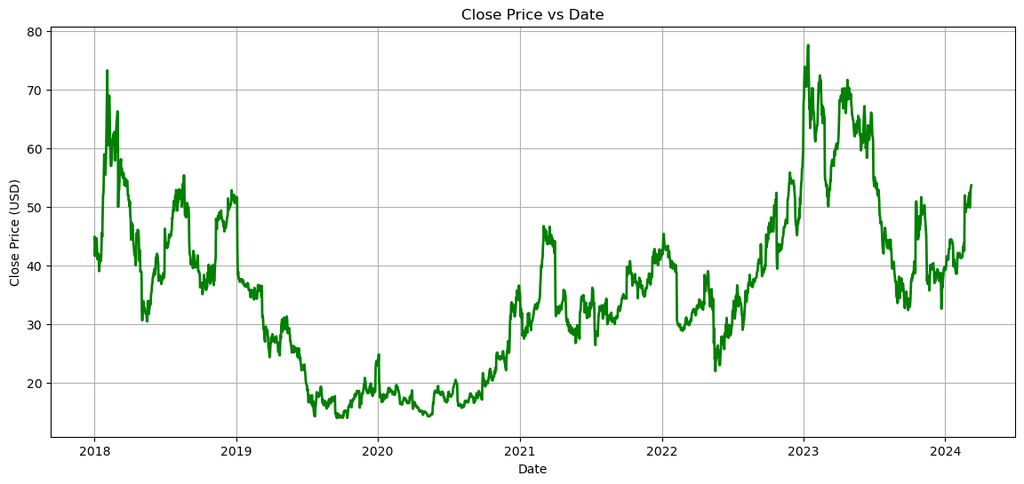

```python
plt.figure(figsize=(14,6))
plt.plot(df['Date'],df['Close'],
         color='green',
         linewidth=2)
plt.title("Close Price vs Date")
plt.xlabel("Date")
plt.ylabel("Close Price (USD)")
plt.grid(True)
plt.show()
```

## Interpretation

The closing price changed significantly over time. The chart shows periods of upward and downward trends, reflecting changes in investor sentiment and market conditions. The stock experienced strong growth during 2022-23 followed by noticeable corrections, demonstrating the volatile nature of Twitter's stock.

# Task3.3 Interactive Time Period Buttons

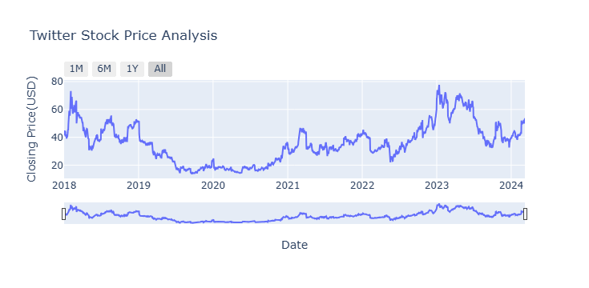

```python
import plotly.graph_objects as go
fig = go.Figure()
fig.add_trace(
    go.Scatter(
        x=df["Date"],
        y=df["Close"],
        mode="lines",
        name="Close Price"
    )
)
fig.update_layout(
    title="Twitter Stock Price Analysis",
    xaxis_title="Date",
    yaxis_title="Closing Price(USD)"
)
fig.update_xaxes(
    rangeslider_visible=True,
    rangeselector=dict(
        buttons=[
            dict(count=1,label="1M",
step="month",stepmode="backward"),
            dict(count=6,label="6M",
step="month",stepmode="backward"),
            dict(count=1,label="1Y",
step="year",stepmode="backward"),
            dict(step="all",label="All")
        ]
    )
)
fig.show()
```

## Interpretation

The interactive visualization allows users to analyze Twitter's stock price across different time periods. The range selector buttons and slider make it easy to explore both short-term and long-term trends. This improves data exploration and helps identify important market movements efficiently.

# Task3.4 Complete Timeline of Twitter Stock Market

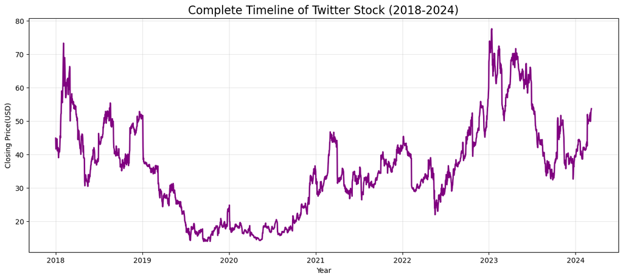

```python
plt.figure(figsize=(15,6))
plt.plot(df["Date"],df["Close"],
         color="purple",
         linewidth=2)
plt.title("Complete Timeline of Twitter Stock (2018-2024)",fontsize=16)
plt.xlabel("Year")
plt.ylabel("Closing Price(USD)")
plt.grid(alpha=0.3)
plt.show()
```

## Timeline Analysis

The complete timeline illustrates Twitter's stock price movement from 2018 to 2024. The stock experienced substantial fluctuations, with periods of decline, recovery and rapid growth. The highest prices were observed during 2023, followed by corrections before stabilizing in 2024. This timeline provides a comprehensive view of Twitter's historical stock performance.

# Task3.5 Insights & Word Cloud

```python
!pip install wordcloud
```

```
Downloading wordcloud-1.9.6-cp313-cp313-win_amd64.whl (306 kB)
```

```python
from wordcloud import WordCloud
import matplotlib.pyplot as plt
```

```python
text="""
Twitter stock price
Growth
Decline
Recovery
Volatility
Market
Investment
Trend
Stock
Shares
Trading
Price
Closing Price
High
Low
Increase
Decrease
Bullish
Bearish
Performance
Timeline
Analysis
Visualization
"""
```

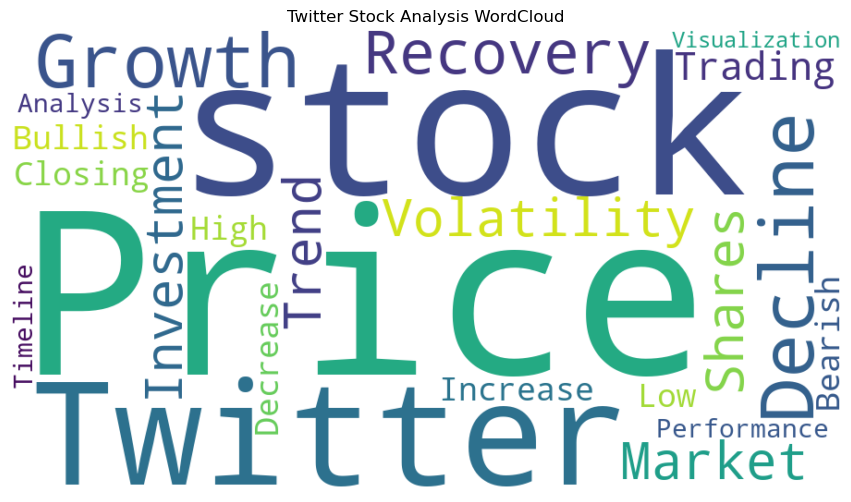

```python
wordcloud = WordCloud(
    width=900,
    height=500,
    background_color="white"
).generate(text)
plt.figure(figsize=(12,6))
plt.imshow(wordcloud,
interpolation="bilinear")
plt.axis("off")
plt.title("Twitter Stock Analysis WordCloud")
plt.show()
```

## Insights

- Twitter's stock experienced high volatility throughout the period.
- Significant growth occurred during 2022-23.
- Stock prices declined sharply during market corrections.
- The interactive visualizations help identify long-term and short-term trends.
- Closing prices closely followed movements in high prices.
- The word cloud summarizes the major concepts identified during the analysis.